# Trait-matching model

We ask how a pollinator’s traits shape its contribution to plant functional diversity, going through the network. The question sits on two axes, trait space vs network and pollinator vs plant, which the SEM of Species contributions makes explicit. In the Coux data, the network row of that SEM works but the trait row does not. Is that what trait matching predicts? We build a minimal trait-matching model, fit the same SEM to simulated networks, and ask how its paths vary with the strength of trait matching, with richness, and with the link between a species’ breadth and its position.

## Model

Plants and pollinators sit in a shared space of two traits, each drawn from a standard normal. Each species also has a niche breadth $\sigma$, log-normal within its guild. A plant $i$ and a pollinator $j$ interact in proportion to the overlap of their Gaussian niches, which decreases with their trait distance $d_{ij}$:

$$w_{ij} = (1 - \lambda) \frac{e^{-d_{ij}^2 / 2(\sigma_i^2 + \sigma_j^2)}}{\bar w} + \lambda$$

where $\lambda$ is the share of interactions independent of traits: $\lambda = 0$ is pure trait matching, $\lambda = 1$ a random network. This is the trait-matching (“complementarity”) rule of mutualistic network models, with a niche breadth for both guilds. Within each guild, log breadth is correlated with the distance to the guild’s centroid with coefficient $\rho$: peripheral species are generalists if $\rho > 0$, specialists if $\rho < 0$. Links are drawn with probabilities proportional to $w_{ij}$, scaled so that each plant has 2 pollinators on average. A species left without a partner gets its most likely one. As in Coux, there are about 0.65 pollinators per plant and plants have 2 pollinators on average (`simulate_network()` in `R/simulation.R`).

Below, a network under pure trait matching ($\rho = 0$): plants (orange squares, sized by breadth) and pollinators (blue dots), with links in grey. Three pollinators are highlighted, with the narrowest, the median and the widest niche (circle of radius $\sigma_j$). Broad plants are reached from further away.

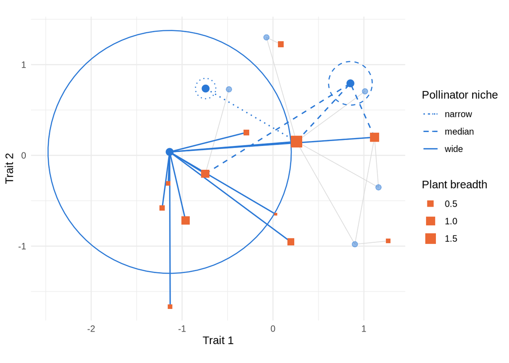

```r
plot_simulated_network(tar_read(sim_example))
```

## Breadth, position and contributions

As in Coux:

- **breadth** is the niche breadth $\sigma$ (log scale): the pollinator’s, and the mean of the plants it visits;
- **position** is originality, the distance to the centroid of the species’ own guild in trait space: the pollinator’s, and the mean of the plants it visits;
- $\Delta R_i$ and $\Delta FD_i$ are computed as in Coux, with plant FD from an average-linkage dendrogram of plant traits and 50 random removal orders (`simulate_pollinator_data()`).

We simulate 30 networks for each combination of $\lambda \in \{0, 0.25, 0.5, 0.75, 1\}$, $\rho \in \{-0.5, 0, 0.5\}$ and 5, 10, 15 or 20 plants (3, 6, 10 and 13 pollinators), the size of the Coux networks.

**Why originality for position.** Plant uniqueness (distance to the nearest plant) explains $\Delta FD_i$ beyond $\Delta R_i$ slightly better than plant originality, but originality carries the matching between pollinator and plant positions far better, because the distance to a centroid is less noisy than the distance to a single neighbour. Under trait matching ($\lambda = 0$, $\rho = 0$), median Spearman correlations across networks:

```r
tar_read(sim_position_metrics) |>
  filter(lambda == 0, rho == 0) |>
  group_by(n_plants, metric) |>
  summarise(across(c(matching, fd), median), .groups = "drop") |>
  mutate(chain = matching * fd) |>
  pivot_wider(names_from = metric, values_from = c(matching, fd, chain)) |>
  mutate(across(-n_plants, \(x) round(x, 2))) |>
  select(n_plants, matching_originality, matching_uniqueness,
         fd_originality, fd_uniqueness, chain_originality, chain_uniqueness) |>
  knitr::kable(col.names = c(
    "Plants", "Matching: originality", "Matching: uniqueness",
    "ΔFD: originality", "ΔFD: uniqueness",
    "Chain: originality", "Chain: uniqueness"
  ))
```

| Plants | Matching: originality | Matching: uniqueness | ΔFD: originality | ΔFD: uniqueness | Chain: originality | Chain: uniqueness |
| --- | --- | --- | --- | --- | --- | --- |
| 5 | 0.50 | 0.00 | NA | NA | NA | NA |
| 10 | 0.37 | 0.29 | 0.35 | 0.46 | 0.13 | 0.13 |
| 15 | 0.33 | 0.07 | 0.46 | 0.50 | 0.15 | 0.03 |
| 20 | 0.42 | 0.12 | 0.32 | 0.54 | 0.13 | 0.06 |

“Matching” is the correlation between a pollinator’s position and that of the plants it visits; “ΔFD” between the plants’ position and the residual of $\Delta FD_i$ on $\Delta R_i$; “chain” is their product.

## The grid SEM in the model

We fit the Coux SEM to batches of 15 simulated networks, like the Coux sites, with a site random effect (`fit_simulated_sem()`). Below, one batch under pure trait matching ($\lambda = 0$, $\rho = 0$, 20 plants).

```r
sem_example <- tar_read(sim_sem_example)
example_summary <- summarise_contribution_sem(sem_example$sem, sem_example$data)
```

```
Random effect variances not available. Returned R2 does not account for random effects.
```

```
Random effect variances not available. Returned R2 does not account for random effects.
```

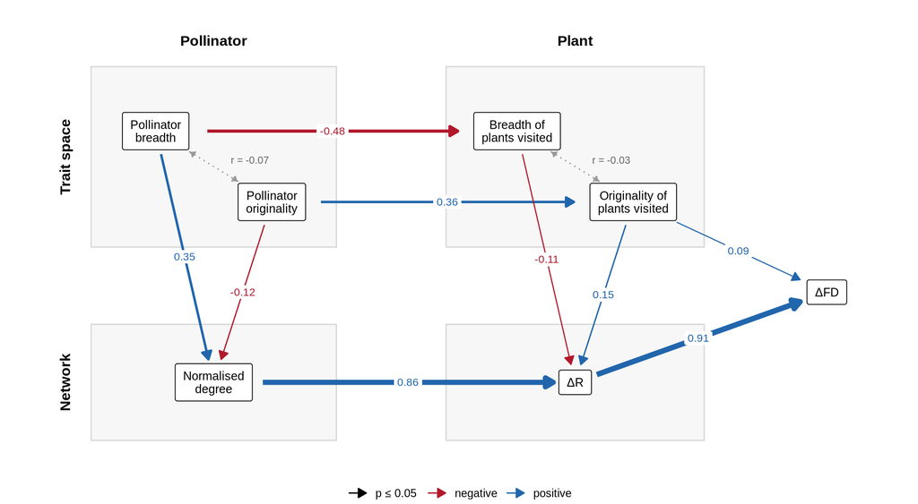

```r
plot_sem_paths(sem_example$sem, sem_example$data)
```

Every path along the two axes is present: breadth and position set degree (down, pollinator), narrow pollinators reach broad plants and peripheral ones peripheral plants (across, trait space), degree sets how many plants depend on the pollinator (across, network), and narrow or peripheral plants depend more on their pollinators (down, plant). With 195 pollinators, the tests still detect smaller paths across the axes (Fisher’s C = 33.7, df = 20, p = 0.028; see below).

**How the paths vary with trait matching and richness** ($\rho = 0$; each setting gives two SEMs; dashed lines show the Coux estimates):

```r
sim_sems <- tar_read(sim_sems)
failed <- if ("error" %in% names(sim_sems)) sum(!is.na(sim_sems$error)) else 0
sim_sems <- filter(sim_sems, !is.na(path))
coux <- tar_read(contribution_sem_summary)
sim_mean <- function(p, lam = 0, r = 0, plants = NULL) {
  keep <- sim_sems$path == p & sim_sems$lambda %in% lam & sim_sems$rho %in% r
  if (!is.null(plants)) keep <- keep & sim_sems$n_plants %in% plants
  sprintf("%.2f", mean(sim_sems$std[keep]))
}
coux_std <- function(p) {
  co <- coux$coefficients
  sprintf("%.2f", co$Std.Estimate[paste(co$Predictor, "->", co$Response) == p])
}
fits <- distinct(sim_sems, n_plants, lambda, rho, batch, fisher_p, missing)
```

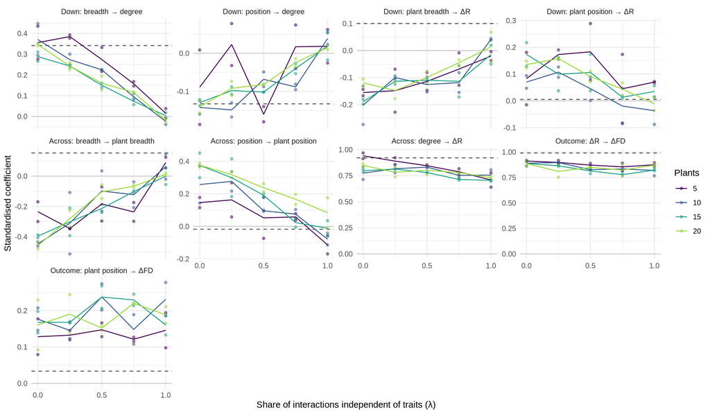

```r
plot_simulated_sems(sim_sems, coux$coefficients, colour_by = "n_plants")
```

- **Every trait path needs trait matching.** All paths from traits fade to zero as interactions become random (e.g. breadth → degree, from 0.34 at $\lambda = 0$ to -0.01 at $\lambda = 1$). The network row (degree → $\Delta R_i$ → $\Delta FD_i$) and plant position → $\Delta FD_i$ hold at any $\lambda$: they follow from how the contributions are built.
- **Breadth paths have the signs of niche overlap.** Narrow pollinators reach broad plants (breadth → plant breadth, -0.38), and pollinators visiting narrow plants contribute more to robustness (plant breadth → $\Delta R_i$, -0.17): narrow plants depend more on each pollinator.
- **Position needs richness, breadth does not.** Position → plant position rises from 0.15 with 5 plants to 0.38 with 20, as positions are estimated from more species; breadth paths barely change.

**How the paths vary with the breadth-position correlation** (averaged over richness):

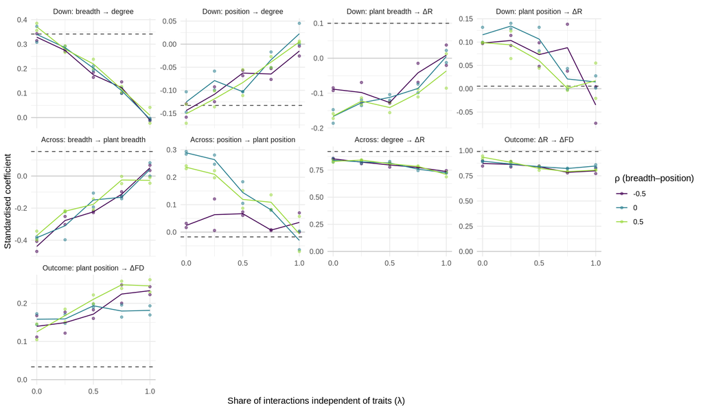

```r
plot_simulated_sems(sim_sems, coux$coefficients, colour_by = "rho")
```

- **When peripheral species are specialists ($\rho < 0$), position matching vanishes** (position → plant position, 0.02 at $\lambda = 0$, against 0.29 at $\rho = 0$): a peripheral specialist only reaches the few plants next to it, which need not be peripheral themselves.
- **$\rho$ sets the breadth-position correlation of the plants visited**, which the SEM absorbs as correlated errors; the other paths change little.

**Coux against the model.** Coux matches the model under trait matching on the pollinator column and the network row: breadth → degree (0.34; model at $\lambda = 0$: 0.34), position → degree (-0.13; -0.13), and a stronger network row. It departs on the trait row and the plant column. Position → plant position (-0.02) is what the model gives without trait matching ($\lambda = 1$: -0.03). The two plant-breadth paths are weak and positive where the model has them negative: breadth → plant breadth 0.15 (model -0.38) and plant breadth → $\Delta R_i$ 0.10 (model -0.17). The Coux pollinator traits behave as trait matching predicts; the plant traits we used (inflorescence symmetry for breadth, the full trait table for position) do not.

**Missing paths.** With hundreds of pollinators per SEM, the d-separation tests reject 62 of 120 simulated SEMs, more often in richer networks. The paths they flag cross the two axes:

```r
tibble(path = unlist(strsplit(fits$missing, "; "))) |>
  filter(path != "") |>
  count(path, sort = TRUE) |>
  head(6) |>
  knitr::kable(col.names = c("Missing path", paste("SEMs flagging it, out of", nrow(fits))))
```

| Missing path | SEMs flagging it, out of 120 |
| --- | --- |
| partner_breadth ~ normalised_degree | 48 |
| delta_r ~ breadth_z | 38 |
| delta_r ~ originality_z | 26 |
| partner_breadth ~ originality_z | 25 |
| partner_originality ~ breadth_z | 25 |
| partner_originality ~ normalised_degree | 22 |

The most frequent, degree → breadth of the plants visited, is a mechanical effect: a pollinator with many partners visits plants of average breadth. These paths are small, and Coux, with 89 records, has little power to detect them.